# Praca domowa 2

Michał Syrkiewicz

## Dane

Dane wykorzystane w Pracy domowej 2 opisują wycenę nieruchmości. Każda obserwacja jest pewną nieruchmością, która posiada informacje takie jak powierzchnia, liczba pokoi, liczba łazienek i wiele więcj. Opis wszystkich kolumn w pliku `README.md`.

## Zadanie 1

Jak wygląda rozkład ceny nieruchomości w poszczególnych kodach pocztowych na przestrzeni lat? Rozważamy kody pocztowe, które mają więcej niż 280 posiadłości.

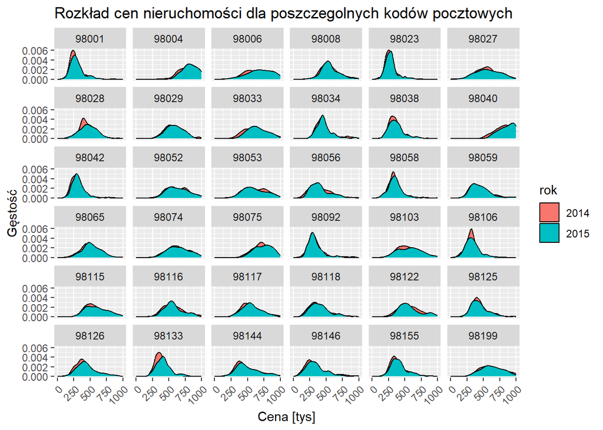

```r
tmp <- df %>% group_by(zipcode) %>% summarise(Liczba = n(),.groups = "drop") %>% filter(Liczba > 280) %>% ungroup()

ans1 <- df %>% filter(zipcode %in% tmp$zipcode) %>% mutate(rok = substr(date,0,4)) %>% mutate(price_tous = price/1000)

ggplot(ans1, aes(x = price_tous, fill = rok)) +
  geom_density() +
  facet_wrap(~zipcode) +
  scale_x_continuous(limits = c(0, 10^3))+
  theme(axis.text.x = element_text(angle = 45, hjust = 1))+
  labs(x="Cena [tys]", y="Gęstość", title = "Rozkład cen nieruchomości dla poszczegolnych kodów pocztowych")
```

**Komentarz: W każdym kodzie pocztowym ceny na przestrzeni lat zostają podobne (wyjątek kod 98106 i 98028). W naszych danych znajdują się kody pocztowe o wysokich cenach nieruchomości np. 98040, jak i stosunkowo niskich np.98001. W wększości ceny układają się na podobnym poziomie.**

## Zadanie 2

Czy jest różnica w rozkładzie ceny nierchomości od powierzchni mieszkalnej uwzględniając podział na nieruchomości z piwnicą i bez?

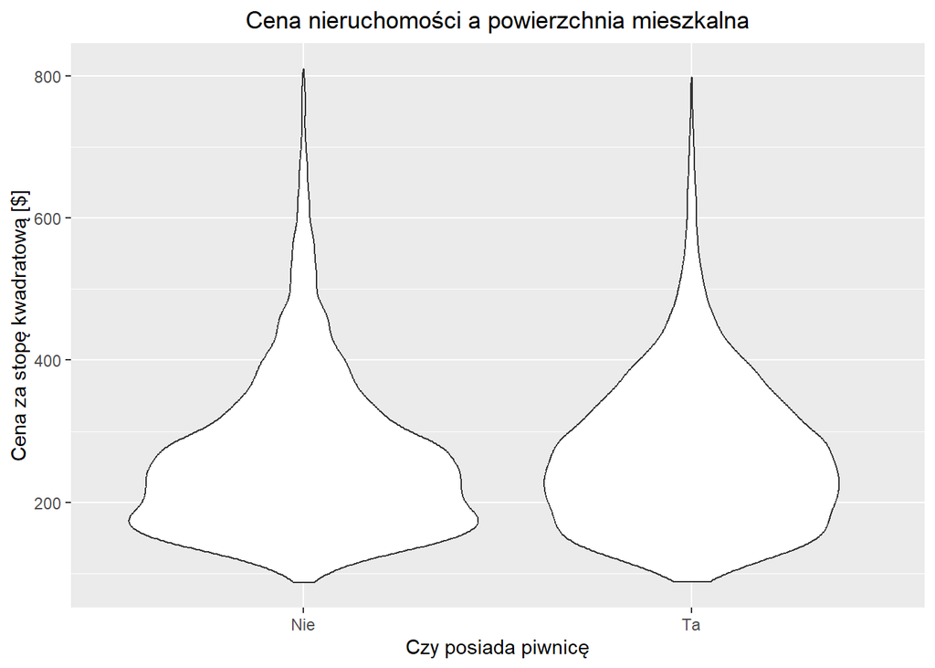

```r
# Tu umieść kod do wygenerowania odpowiedzi do zadania.

ans2 <- df %>%
  mutate(czy_Piwnica = case_when(
    sqft_basement == 0 ~ "Nie",
    TRUE ~ "Ta"), cena_sqft = price/sqft_living) %>% mutate(price_tous = price/1000)
ggplot(ans2, aes(x=factor(czy_Piwnica), y=cena_sqft)) + geom_violin() + labs(x="Czy posiada piwnicę", y="Cena za stopę kwadratową [$]", title = "Cena nieruchomości a powierzchnia mieszkalna")+  theme(plot.title = element_text(hjust=0.5))
```

**Komentarz: Różnica jest niezauważalna przy niskich cenach za stopę kwadratową. W domach o średniej wartości ceny za stopę kwadratową widać, że przeważają domy z piwnicą, ale jest to marginalna różnica. Brak różnicy także przy drogich nieruchomościach.**

## Zadanie 3

Jaka jest zależność pomiędzy jakością wykończenia nieruchomości a liczbą pięter?

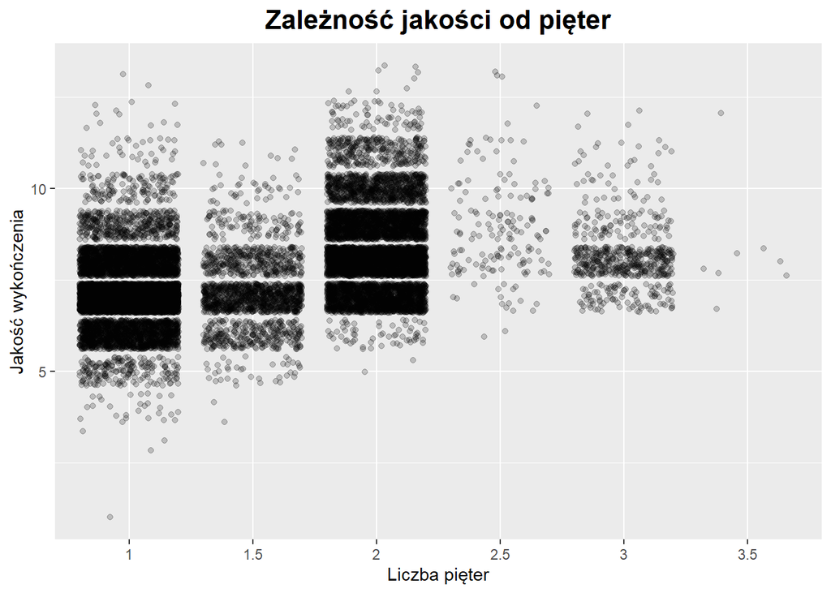

```r
# Tu umieść kod do wygenerowania odpowiedzi do zadania.

ans3 <- df %>% group_by(floors) %>% mutate(Srednia_jakosc = mean(grade)) %>% ungroup()
ggplot(data = ans3, aes(x= factor(floors), y=grade, ))+ geom_jitter(alpha = 0.2)+ labs(title = "Zależność jakości od pięter", x= "Liczba pięter", y="Jakość wykończenia") +  theme(
    plot.title = element_text(
      hjust = 0.5,
      size = 16,
      face = "bold",
      color = "black"
    )
  )
```

**Komentarz: Różnica nie jest ogromna. Większość domów ma jakość wykończenia na poziomie 7-8. Można jednak zauważyc, że im większa liczba pięter tym jakość wykończena idzie w górę oraz jest coraz mniej domów z gorszą jakością. Jest to szczególnie widoczne przy przeskoku z 1 piętra do 2 pięter, gdzie główny przedział jakości zmienia się z 6-8 na 7-9 (przy praktycznym braku domów z wartością jakości 6)**

## Zadanie 4

Jaka jest zależność między powierzchnią mieszkalną nieruchomości a powierzchnią gruntu w podziale na liczbę sypialni?

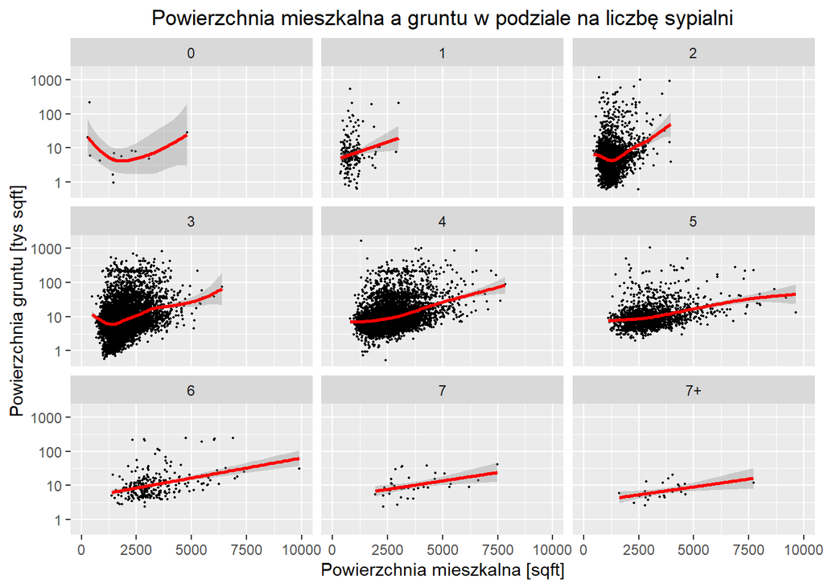

```r
# Tu umieść kod do wygenerowania odpowiedzi do zadania.

df %>% mutate(bedrooms = case_when(bedrooms >7 ~"7+", .default = as.character(bedrooms)), grunt= sqft_lot/1000) %>% filter(!(bedrooms==2 & sqft_living > 5000))%>% ggplot(aes(x = sqft_living, y = grunt)) + geom_point(size =.3) + scale_y_log10() + geom_smooth(method = "gam", formula = y ~ s(x, k = 10), col = "red") + facet_wrap(~ bedrooms) + labs(title = "Powierzchnia mieszkalna a gruntu w podziale na liczbę sypialni", x = "Powierzchnia mieszkalna [sqft]", y = "Powierzchnia gruntu [tys sqft]") + scale_x_continuous(limits= c(0,10000)) + scale_y_log10() + theme(plot.title = element_text(hjust = 0.5))
```

**Komentarz: Zależność jest marginalna. Wraz ze wzrostem powierzchni nieruchomości można dopatrzeć się także wzrostu powierzchni gruntu, dla każdej wartości sypialni można znaleźć mieszkanie przeczące temu stwierdzeniu, co nie wyklucza istnienia małego wzrostu (czerwona krzywa przybliżająca trend). Dla dużych ilości sypialni mało danych, dlatego 7+ połączone w jedną kategorię.**

## Zadanie 5

Rozważmy tylko nieruchomości, które miały remont. W której dekadzie było najwięcej przeprowadzonych remontów? Czy w poszczególnych dekadach jest porównywalny procent nieruchmości dla każdej wartości miary jakości i wykończenia nieruchomości?

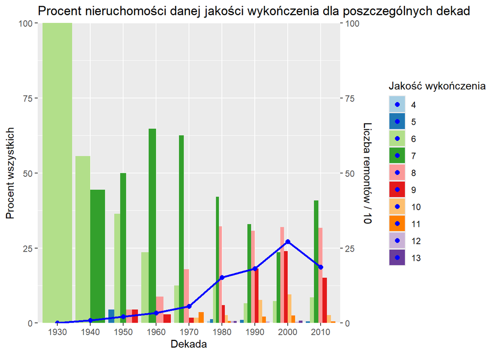

```r
# Tu umieść kod do wygenerowania odpowiedzi do zadania.

# Preparing tmp5 as before
tmp5 <- df %>%
  filter(yr_renovated != 0) %>%
  mutate(dekada = floor(yr_renovated / 10) * 10) %>%
  group_by(dekada) %>%
  summarise(Liczba_R = n()/10) %>%
  ungroup()

# Creating the main plot with renovation percentages and adding the renovation count line
tmp5 <- df %>%
  filter(yr_renovated != 0) %>%
  mutate(dekada = 10 * floor(yr_renovated / 10)) %>%
  group_by(dekada, grade) %>%
  summarise(Liczba_R1 = n()) %>%
  ungroup() %>%
  left_join(tmp5, by = "dekada") %>%
  mutate(procent = 10 * Liczba_R1/ Liczba_R)
  ggplot(tmp5, aes(x = as.factor(dekada), y = procent, fill = as.factor(grade))) +
  geom_col(position = "dodge") +
  scale_fill_brewer(palette = "Paired") +
  labs(
    title = "Procent nieruchomości danej jakości wykończenia dla poszczególnych dekad",
    y = "Procent wszystkich", x = "Dekada", fill = "Jakość wykończenia"
  ) +
  scale_y_continuous(expand = c(0, 0), sec.axis = sec_axis(~., name = "Liczba remontów / 10")) +

  # Adding the line plot for the number of renovations in each decade
  geom_line( aes(x = as.factor(dekada), y = Liczba_R, group = 1), color = "blue", size = 1) +
  geom_point( aes(x = as.factor(dekada), y = Liczba_R), color = "blue", size = 2)
```

**Komentarz: Najwięcej remontów było w dekadzie 2000. Pomijając pierwsze dwie dekady, dla których za mało jest danych. Można zaobserwować, że jakość wykończenia rośnie wraz z upływającym czasem. Do lat 1970 przeważa jakość 7 i o ile jest jej najwięcej także w następnych dekadach, to jej udział maleje kosztem jakości 8, a nawet 9. Ciekawym przypadkiem są domy wyremontowane w latach 2000 - 2009, gdzie jako jedyna przeważa jakość 8.**

## Zadanie 6

Jak prezentuje się wartość minimalna, średnia i maksymalna ceny nieruchmości w podziele na rok budowy nieruchomości.

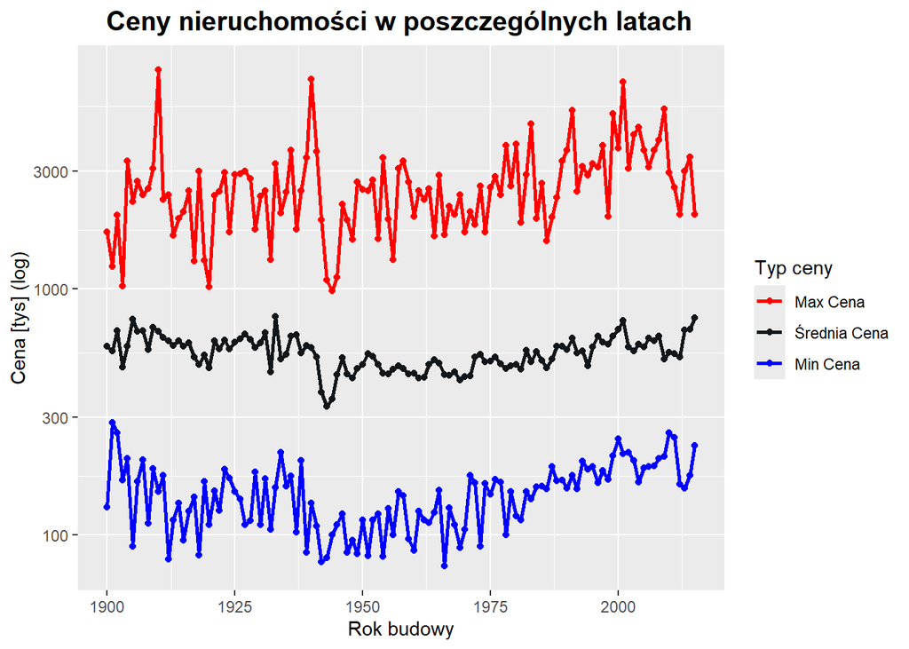

```r
# Tu umieść kod do wygenerowania odpowiedzi do zadania.


tmp <- df %>% group_by(yr_built) %>%
  summarize(min_price = min(price),
            max_price = max(price),
            mean_price = mean(price))
ggplot(tmp, aes(x = yr_built)) +
  geom_line(aes(y = min_price/1000, color = "Min Cena"),size=1) +
  geom_line(aes(y = max_price/1000, color = "Max Cena"),size=1) +
  geom_line(aes(y = mean_price/1000, color = "Średnia Cena"),size=1) +
  geom_point( aes(y = min_price/1000,color = "Min Cena"), , size =1.5) +
  geom_point( aes(y = max_price/1000, color = "Max Cena"), size = 1.5) +
  geom_point( aes(y = mean_price/1000, color = "Średnia Cena"), size = 1.5)+
  scale_y_log10() +
  scale_color_manual(values = c("Max Cena" = "red",
                                 "Średnia Cena" = "#121619",
                                 "Min Cena" = "blue"),
                     breaks = c("Max Cena", "Średnia Cena", "Min Cena")) +
  labs(x = "Rok budowy",
       y = "Cena [tys] (log)",
       title = "Ceny nieruchomości w poszczególnych latach",
       color = "Typ ceny") +
  theme(plot.title = element_text(size = 15, face = "bold", hjust = 0.47))
```

**Komentarz: Wszystkie 3 wartości zachowują stałą zmienność (Jeśli cena maksymalna rośnie podobnie dzieje się z minimalną).Średnia wartość utrzymuje się na stałym poziomie bez znaczenia na rok budowy.**